# Weight Lifting Exercise

Shane Mooney

August 7, 2016

# Setup

Libraries and seed

```r
library(caret)
set.seed(123)
```

Utilities:

```r
modelAccuracy <- function(model, testData) {
  prediction <- predict(model, testData)
  accuracy <- sum(prediction == testData$classe) / nrow(testData)
  accuracy
}
```

Loading data:

```r
pmlTraining <- read.csv("pml-training.csv")
pmlTesting <- read.csv("pml-testing.csv")
```

# Cleaning data

We exclude some data from our training and validation data sets: - rows with new_window == “yes” because the data in these rows looks different than other rows, and because no records in the test data set have “yes” for this column - columns either either NA or empty values. These columns are extremely sparesely populated, most having absolutely no actual values (after excluding new_window == “yes” rows), so we should be able to safely ignore them - We also disregard `X`, `new_window`, `num_window`, `cvtd_timestamp`, `raw_timestamp_part_1`, and `raw_timestamp_part_2` because the nature of these columns implies that they should have no predictive value

```r
goodPmlTraining <- pmlTraining[pmlTraining$new_window == "no", ]
goodPmlTraining <- goodPmlTraining[, colSums(is.na(goodPmlTraining)) == 0]
goodPmlTraining <- goodPmlTraining[, colSums(goodPmlTraining == "") == 0]

goodPmlTraining <- goodPmlTraining[ , !(names(goodPmlTraining) %in% c('X', 'new_window', 'num_window', 'cvtd_timestamp', 'raw_timestamp_part_1', 'raw_timestamp_part_2'))]
```

# Exploratory model training

Using a very small exploratory data set

```r
exploration <- goodPmlTraining[sample(nrow(goodPmlTraining), size=1000), ]
```

```r
glmModel <- train(subset(exploration, TRUE, -c(classe)), exploration$classe, model="glm")
gbmModel <- train(subset(exploration, TRUE, -c(classe)), exploration$classe, model="gbm")
```

```r
rfModel <- train(subset(exploration, TRUE, -c(classe)), exploration$classe, model="rf")
```

# Exploratory model accuracy

Validating these models against the entire training set:

```r
print(paste("GLM model accuracy: ", modelAccuracy(glmModel, goodPmlTraining)))
```

```
## [1] "GLM model accuracy:  0.880776436303081"
```

```r
print(paste("GBM model accuracy: ", modelAccuracy(gbmModel, goodPmlTraining)))
```

```
## [1] "GBM model accuracy:  0.884159034138218"
```

```r
print(paste("Random forest model accuracy: ", modelAccuracy(rfModel, goodPmlTraining)))
```

```
## [1] "Random forest model accuracy:  0.882233555370525"
```

# Variable importance

Examining the top 20 most important predictors, as reported by the exploratory random forest:

```r
varImp(rfModel)
```

```
## rf variable importance
##
##   only 20 most important variables shown (out of 53)
##
##                   Overall
## roll_belt          100.00
## pitch_forearm       88.28
## magnet_dumbbell_z   75.73
## yaw_belt            71.66
## magnet_belt_y       68.89
## magnet_dumbbell_y   64.68
## roll_dumbbell       64.00
## accel_forearm_x     62.94
## magnet_belt_z       62.62
## accel_arm_x         62.36
## magnet_dumbbell_x   62.09
## magnet_arm_x        59.83
## accel_belt_z        59.32
## magnet_arm_y        58.21
## pitch_belt          57.77
## accel_dumbbell_y    55.18
## roll_forearm        51.48
## accel_dumbbell_x    49.97
## pitch_dumbbell      48.27
## magnet_forearm_x    47.51
```

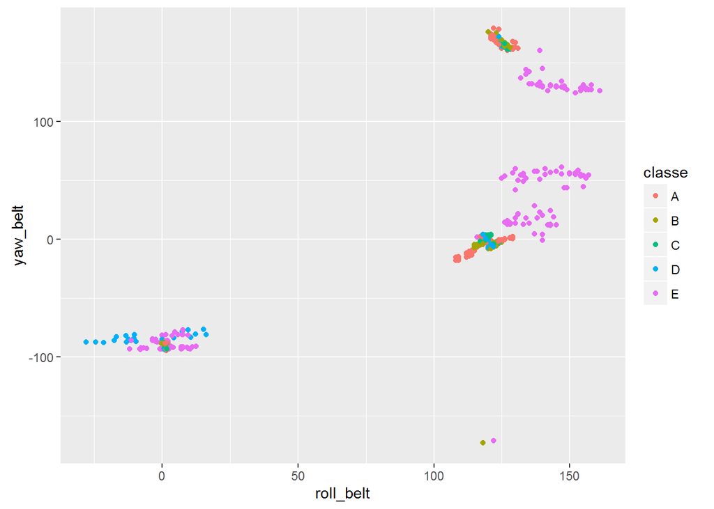

```r
qplot(roll_belt, yaw_belt, colour = classe, data = exploration)
```

We see some very clear trends with these two predictors alone

# Training final model

Because of strength of exploratory models and slowness of building them, we’ll choose a relatively small subset of the training data to train our final model on, reserving the remainder for validation

```r
trainingSampleSize <- floor(0.25 * nrow(goodPmlTraining))
trainingIndices <- sample(seq_len(nrow(goodPmlTraining)), size = trainingSampleSize)

training <- goodPmlTraining[trainingIndices, ]
validation <- goodPmlTraining[-trainingIndices, ]
```

```r
finalModel <- train(subset(training, TRUE, -c(classe)), training$classe, model="rf")
```

# Validation

We evaluate our model against the validation data set

```r
print(paste("Accuracy on validation data set: ", modelAccuracy(finalModel, validation)))
```

```
## [1] "Accuracy on validation data set:  0.975090202608937"
```

We expect the model’s accuracy on the validation data set to be a very good estimate of out of sample error rate, because it’s a large sample with no overlap with the training set

# Testing

```r
testPredictions <- predict(finalModel, pmlTesting[, colnames(finalModel$trainingData)[0:(length(finalModel$trainingData) - 1)]])
print("Test predictions:")
```

```
## [1] "Test predictions:"
```

```r
data.frame(testPredictions)
```

```
##    testPredictions
## 1                B
## 2                A
## 3                B
## 4                A
## 5                A
## 6                E
## 7                D
## 8                D
## 9                A
## 10               A
## 11               B
## 12               C
## 13               B
## 14               A
## 15               E
## 16               E
## 17               A
## 18               B
## 19               B
## 20               B
```

# Citations

Velloso, E.; Bulling, A.; Gellersen, H.; Ugulino, W.; Fuks, H. Qualitative Activity Recognition of Weight Lifting Exercises. Proceedings of 4th International Conference in Cooperation with SIGCHI (Augmented Human ’13) . Stuttgart, Germany: ACM SIGCHI, 2013.

Read more: http://groupware.les.inf.puc-rio.br/har#ixzz4GhRgF9oF

# Licenses

Important: you are free to use this dataset for any purpose. This dataset is licensed under the Creative Commons license (CC BY-SA). The CC BY-SA license means you can remix, tweak, and build upon this work even for commercial purposes, as long as you credit the authors of the original work and you license your new creations under the identical terms we are licensing to you. This license is often compared to “copyleft” free and open source software licenses. All new works based on this dataset will carry the same license, so any derivatives will also allow commercial use.